# Stratified Prioritizations

Jeffrey O. Hanson

## Introduction

Conservation planning exercises often need to stratify priority areas across different governmental areas (e.g. counties, countries). For instance, although it may be more efficient to concentrate conservation priorities to a single governmental area, this may not be practical given real-world conservation constraints (e.g. funding availability). Here we will explore some approaches for generating spatial prioritizations that stratify (allocate) selected planning units across different areas (e.g. counties).

## Set up

First, we will load some R packages for this tutorial.

```r
# load packages
library(prioritizr)
library(raster)
library(sf)
library(dplyr)
library(fasterize)
```

Next, we will load some planning unit and feature data. The planning units represent the different places that we could purchase for protected area establishment. Each planning unit has a protected area establishment cost (per `"cost"` column). Additionally, these planning units are organized into counties (per `"county"` column). **In this tutorial, we will assume that it is important for prioritizations to “balance” selected planning units across each of the counties. In other words, we do not want prioritizations that select “too many” planning units within any given county.** The features represent different species that we are interested in conserving, and the feature data indicate the presence (or absence) of each feature within each planning unit.

```r
# load data
data(sim_pu_sf) # planning unit data
data(sim_features) # feature data

# add county data to planning unit data
## here we just assign the counties by subdividing the study area into
## equal sized grid cells, in real-world data the counties should be
## assigned by spatially intersecting the planning unit data with
## a spatial layer denoting the county borders
data(sim_pu_raster)
sim_pu_raster[] <- seq_len(ncell(sim_pu_raster))
county_raster_data <- raster::aggregate(sim_pu_raster, fact = 5, fun = min)
sim_pu_sf$county <-
  sapply(raster::extract(county_raster_data, sim_pu_sf), min)
sim_pu_sf$county <- match(sim_pu_sf$county, sort(unique(sim_pu_sf$county)))
sim_pu_sf$county <- letters[sim_pu_sf$county]

# preview planning unit data
print(sim_pu_sf)
```

```
## Simple feature collection with 90 features and 4 fields
## geometry type:  POLYGON
## dimension:      XY
## bbox:           xmin: 0 ymin: 0 xmax: 1 ymax: 1
## CRS:            NA
## First 10 features:
##        cost locked_in locked_out                       geometry county
## 1  215.8638     FALSE      FALSE POLYGON ((0 1, 0.1 1, 0.1 0...      a
## 2  212.7823     FALSE      FALSE POLYGON ((0.1 1, 0.2 1, 0.2...      a
## 3  207.4962     FALSE      FALSE POLYGON ((0.2 1, 0.3 1, 0.3...      a
## 4  208.9322     FALSE       TRUE POLYGON ((0.3 1, 0.4 1, 0.4...      a
## 5  214.0419     FALSE      FALSE POLYGON ((0.4 1, 0.5 1, 0.5...      a
## 6  213.7636     FALSE      FALSE POLYGON ((0.5 1, 0.6 1, 0.6...      b
## 7  210.4612     FALSE      FALSE POLYGON ((0.6 1, 0.7 1, 0.7...      b
## 8  211.0424     FALSE       TRUE POLYGON ((0.7 1, 0.8 1, 0.8...      b
## 9  210.3878     FALSE      FALSE POLYGON ((0.8 1, 0.9 1, 0.9...      b
## 10 204.3971     FALSE      FALSE POLYGON ((0.9 1, 1 1, 1 0.9...      b
```

```r
# preview feature data
print(sim_features)
```

```
## class      : RasterStack
## dimensions : 10, 10, 100, 5  (nrow, ncol, ncell, nlayers)
## resolution : 0.1, 0.1  (x, y)
## extent     : 0, 1, 0, 1  (xmin, xmax, ymin, ymax)
## crs        : NA
## names      :   layer.1,   layer.2,   layer.3,   layer.4,   layer.5
## min values : 0.6782107, 0.2243090, 0.4147364, 0.2199663, 0.4343547
## max values : 0.9339562, 0.4142271, 0.8390267, 0.5976491, 0.6667633
```

After loading the data, let’s visualize the data.

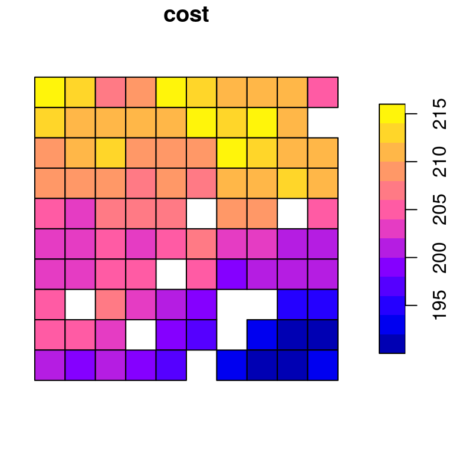

```r
# visualize planning unit cost data
plot(sim_pu_sf[, "cost"], main = "cost")
```

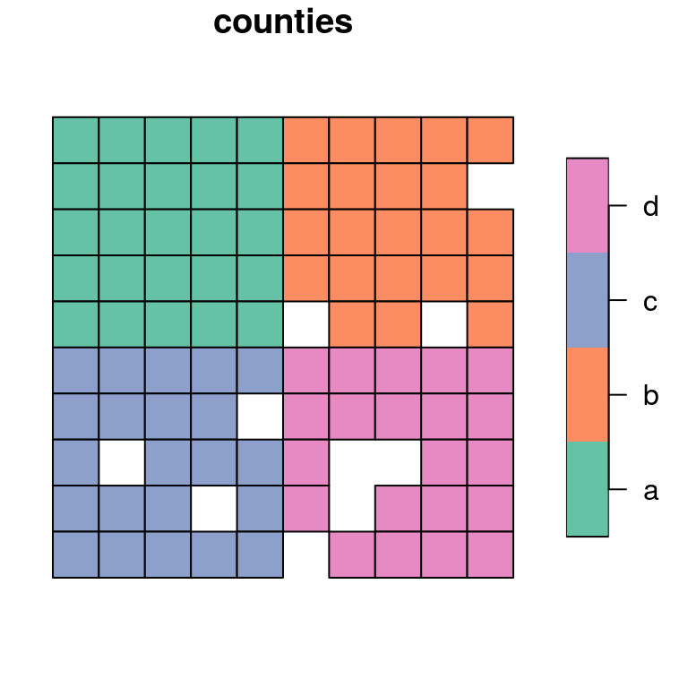

```r
# visualize planning unit county data
plot(sim_pu_sf[, "county"], main = "counties")
```

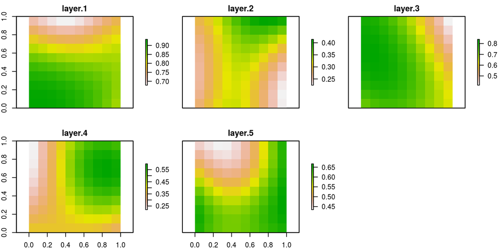

```r
# visualize feature data
plot(sim_features)
```

## Baseline scenario

To start off, let’s keep things simple. Here we will generate a spatial prioritization that does not stratify selected planning units across the counties. In other words, this prioritization will represent our “baseline scenario”. By comparing this prioritization to subsequent prioritizations – that explicitly stratify the planning units across the counties – we can see what effect stratifying planning units has on the solutions. Specifically, this prioritization will be generated following the minimum set formulation of the reserve selection problem and contain targets that require each feature to have 10% of its spatial distribution represented in the solution.

```r
# build baseline problem
p1 <-
  problem(sim_pu_sf, sim_features, cost_column = "cost") %>%
  add_min_set_objective() %>%
  add_relative_targets(0.1) %>%
  add_binary_decisions() %>%
  add_default_solver(verbose = FALSE)

# solve problem to generate baseline prioritization
s1 <- solve(p1)
```

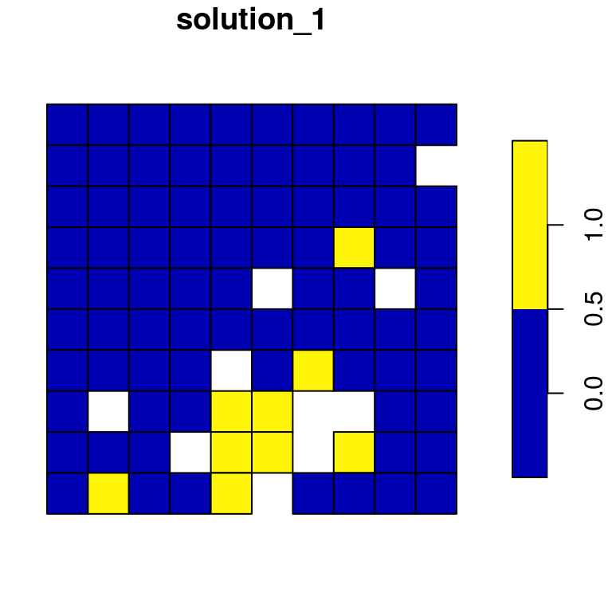

```r
# visualize solution
plot(s1[, "solution_1"])
```

By comparing this map to the previous map showing the different counties, we can see that this solution selects many planning units in located in counties “C” and counties “D”. Indeed, we can calculate how many planning units were selected in each county.

```r
# calculate how many planning units selected in each county
s1_county_results <-
  s1 %>%
  st_drop_geometry() %>%
  group_by(county) %>%
  summarize(n_selected = sum(solution_1)) %>%
  ungroup()
# print result
print(s1_county_results)
```

```
## # A tibble: 4 x 2
##   county n_selected
##   <chr>       <dbl>
## 1 a               0
## 2 b               1
## 3 c               4
## 4 d               4
```

Therefore, we can see that this baseline scenario does not produce a prioritization that is “useful” given the context of this tutorial. So what can we do?

## Minimum allocation constraints

One approach to obtain prioritizations that select planning units that are stratified across the counties is to add constraints that specify the minimum number of selected planning units per county. In other words, we can add constraints to the reserve selection procedure that force the solution to have at least a certain amount of planning units selected within each county.

To achieve this, we need to prepare the county data as extra “features” so that we can add constraints to the problem that relate to the county data. Since our feature data are in raster format, the county data need to be converted to raster format. Here, each county layer will indicate proportion of each planning unit that is covered by each county. Note that all the all proportions with either be 0% or 100% because our planning units match up perfectly with the feature grid cells.

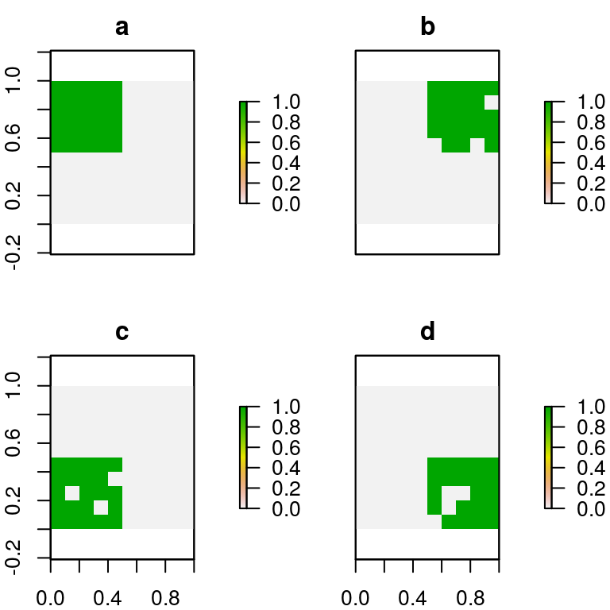

```r
# create a raster stack containing a layer for each county
county_data <- fasterize(sim_pu_sf, sim_features[[1]], background = 0,
                        by = "county")

# plot county raster data
plot(county_data)
```

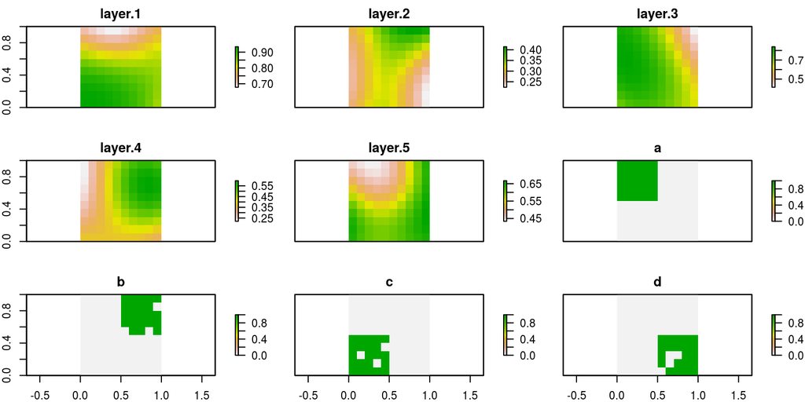

```r
# create new feature data object with the species data and the county data
sim_features2 <- raster::addLayer(sim_features, county_data)

# plot new feature data
plot(sim_features2)
```

Now we can create a prioritization using these data. Similar to the baseline scenario, this prioritization will be generated following the minimum set formulation of the reserve selection problem and contain targets that require each feature to have 10% of its spatial distribution represented in the solution. It will also contain constraints to ensure that each county has *at least* three planning units selected in the prioritization.

```r
# create targets,
# for more information on what this means, see ?add_manual_targets
p2_target_data <-
  tibble(
    feature = names(sim_features2),
    type = c(rep("relative", nlayers(sim_features)),
             rep("absolute", nlayers(county_data))),
    sense = c(rep(">=", nlayers(sim_features)),
              rep(">=", nlayers(county_data))),
    target = c(rep(0.1, nlayers(sim_features)),
               rep(3, nlayers(county_data))))

# print target data
print(p2_target_data)
```

```
## # A tibble: 9 x 4
##   feature type     sense target
##   <chr>   <chr>    <chr>  <dbl>
## 1 layer.1 relative >=       0.1
## 2 layer.2 relative >=       0.1
## 3 layer.3 relative >=       0.1
## 4 layer.4 relative >=       0.1
## 5 layer.5 relative >=       0.1
## 6 a       absolute >=       3
## 7 b       absolute >=       3
## 8 c       absolute >=       3
## 9 d       absolute >=       3
```

```r
# build minimum allocation constraints problem
p2 <-
  problem(sim_pu_sf, sim_features2, cost_column = "cost") %>%
  add_min_set_objective() %>%
  add_manual_targets(p2_target_data) %>%
  add_binary_decisions() %>%
  add_default_solver(verbose = FALSE)

# solve problem to generate prioritization
s2 <- solve(p2)
```

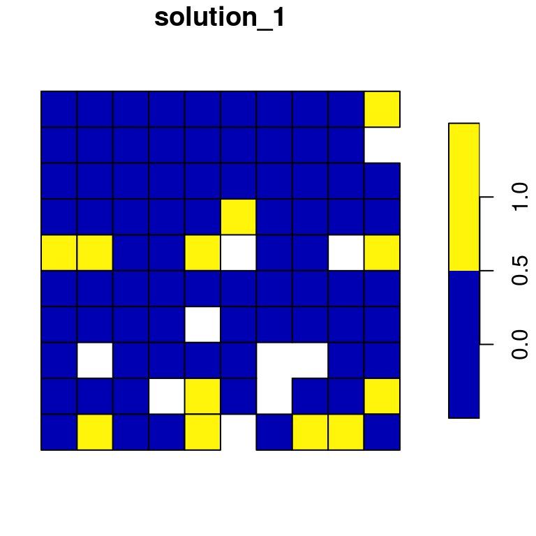

```r
# visualize solution
plot(s2[, "solution_1"])
```

Now let’s calculate the number of planning units selected within each county.

```r
# calculate how many planning units selected in each county
s2_county_results <-
  s2 %>%
  st_drop_geometry() %>%
  group_by(county) %>%
  summarize(n_selected = sum(solution_1)) %>%
  ungroup()
# print result
print(s2_county_results)
```

```
## # A tibble: 4 x 2
##   county n_selected
##   <chr>       <dbl>
## 1 a               3
## 2 b               3
## 3 c               3
## 4 d               3
```

We can see that each county has at least three planning units selected within it. If we use this strategy, then we need to be careful what threshold we use (i.e. how many selected planning units per county, in this example it was 3 planning units), because if we set the threshold too high then we might end up selecting extra planning units that aren’t needed to reach the features’ targets. Let’s calculate the cost of this solution (i.e. `s2`), and compare its cost to that of the baseline scenario (i.e. `s1`).

```r
# calculate s1 cost
s1_cost <- sum(s1$cost * s1$solution_1, na.rm = TRUE)
print(s1_cost)
```

```
## [1] 1792.535
```

```r
# calculate s2 cost
s2_cost <- sum(s2$cost * s2$solution_1, na.rm = TRUE)
print(s2_cost)
```

```
## [1] 2395.786
```

We can see that adding these constraints increases the cost of the solution by a fair amount – so the solution is probably not highly efficient. You could further explore the efficiency by conducting an irreplacebility analysis (see `?irreplaceability`). But there is another approach we could employ that is less sensitive to our choice of threshold.

## Maximum allocation constraints

A different approach would involve setting constraints with specify the maximum – not the minimum – amount of planning units that could be selected per county within the solution. This approach has an advantage over the previous approach because it would not select extra planning units that are not needed to reach the features’ targets.

Now let’s create a prioritization using this approach. Similar to the baseline scenario, this prioritization will be generated following the minimum set formulation of the reserve selection problem and contain targets that require each feature to have 10% of its spatial distribution represented in the solution. It will also contain constraints to ensure that each county has *at most* (not “at least”) three planning units selected in the prioritization.

```r
# create targets,
# for more information on what this means, see ?add_manual_targets
p3_target_data <-
  tibble(
    feature = names(sim_features2),
    type = c(rep("relative", nlayers(sim_features)),
             rep("absolute", nlayers(county_data))),
    sense = c(rep(">=", nlayers(sim_features)),
              rep("<=", nlayers(county_data))),
    target = c(rep(0.1, nlayers(sim_features)),
               rep(3, nlayers(county_data))))

# print target data
print(p3_target_data)
```

```
## # A tibble: 9 x 4
##   feature type     sense target
##   <chr>   <chr>    <chr>  <dbl>
## 1 layer.1 relative >=       0.1
## 2 layer.2 relative >=       0.1
## 3 layer.3 relative >=       0.1
## 4 layer.4 relative >=       0.1
## 5 layer.5 relative >=       0.1
## 6 a       absolute <=       3
## 7 b       absolute <=       3
## 8 c       absolute <=       3
## 9 d       absolute <=       3
```

```r
# build minimum allocation constraints problem
p3 <-
  problem(sim_pu_sf, sim_features2, cost_column = "cost") %>%
  add_min_set_objective() %>%
  add_manual_targets(p3_target_data) %>%
  add_binary_decisions() %>%
  add_default_solver(verbose = FALSE)

# solve problem to generate prioritization
s3 <- solve(p3)
```

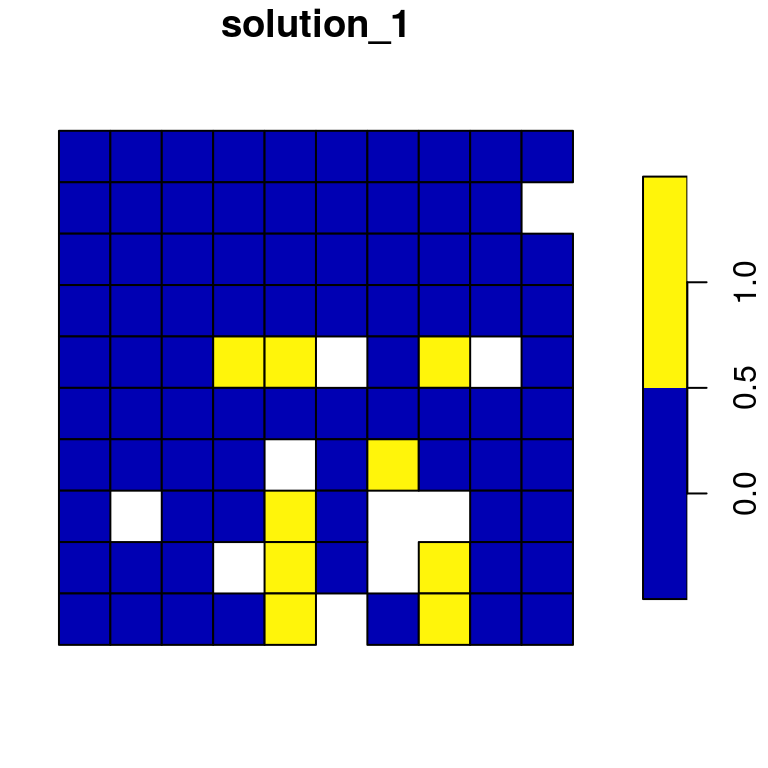

```r
# visualize solution
plot(s3[, "solution_1"])
```

Now let’s calculate the number of planning units selected within each county.

```r
# calculate how many planning units selected in each county
s3_county_results <-
  s3 %>%
  st_drop_geometry() %>%
  group_by(county) %>%
  summarize(n_selected = sum(solution_1)) %>%
  ungroup()
# print result
print(s3_county_results)
```

```
## # A tibble: 4 x 2
##   county n_selected
##   <chr>       <dbl>
## 1 a               2
## 2 b               1
## 3 c               3
## 4 d               3
```

```r
# calculate s3 cost
s3_cost <- sum(s3$cost * s3$solution_1, na.rm = TRUE)
print(s3_cost)
```

```
## [1] 1801.919
```

As we can see, the cost of this new prioritization (i.e. `s3`) is cheaper than that of the previous prioritization (i.e. `s2`) . It is worth noting that the cost of this new prioritization (i.e. `s3`) is still more expensive than the baseline scenario (i.e. `s1`) because we have added constraints that prevent the solution from selecting too many planning units in each county—even if it would be more efficient to do so.